# R Notebook

BIS 581 - Product Sentiment Analysis

# load libraries that you feel you need and explain why

#Explanation:

If libraries are not installed then we use the install.packages function to install them. I did not keep those codes in the chunk but I am writing it down here for clarity.

The tidyverse package is my primary data handling and visualization toolkit. I need it for data cleaning, transformation, and creating ggplot2 visualizations. We know it is a collection of multiple packages such as dplyr or ggplot2.

The tidytext package is essential for removing stop words, and working with sentiment lexicons in a tidy data framework.

I need the wordcloud package for creating word clouds for my analysis.

The textdata package provides access to various sentiment lexicons such as nrc or AFINN.

The igraph and ggraph packages are needed for creating network diagrams and visualizations.

# Load the data from a file

# Assess the data

Before beginning analysis, I need to understand the structure and quality of the dataset. This examination helps identify potential issues like missing values, unusual data types, or structural problems that could affect the analysis results.

```r
# Checking structure to understand variable types and data organization
str(posts)
```

```
'data.frame':   27669 obs. of  18 variables:
 $ Transaction_ID    : int  1 2 3 4 5 6 7 8 9 10 ...
 $ TimeKey           : chr  "2018-1" "2018-1" "2018-1" "2018-1" ...
 $ Year              : int  2018 2018 2018 2018 2018 2018 2018 2018 2018 2018 ...
 $ Week              : int  1 1 1 1 1 1 1 1 1 1 ...
 $ Number_of_Items   : int  4 4 4 3 1 5 3 1 5 2 ...
 $ T_Ounces          : int  24 36 36 24 4 24 16 8 32 8 ...
 $ T_Price           : chr  "$21.00 " "$23.50 " "$22.50 " "$17.00 " ...
 $ T_Cost            : chr  "$8.02 " "$11.71 " "$11.65 " "$7.86 " ...
 $ CustomerID        : int  NA NA NA NA NA NA NA NA NA NA ...
 $ Star_Rating       : int  NA NA NA NA NA NA NA NA NA NA ...
 $ Comment           : chr  "" "" "" "" ...
 $ Chocolate         : int  1 1 0 0 1 1 1 0 1 1 ...
 $ Feature           : int  2 2 3 0 0 1 1 1 3 1 ...
 $ Superman          : int  0 0 1 0 0 1 1 0 0 0 ...
 $ Vanilla           : int  1 1 0 3 0 2 0 0 1 0 ...
 $ FeatureFlavor     : chr  "Superman" "Superman" "Superman" "Superman" ...
 $ ParlorLocation    : chr  "Alpena" "Alpena" "Alpena" "Alpena" ...
 $ ProductionLocation: chr  "Mount Pleasant" "Mount Pleasant" "Mount Pleasant" "Mount Pleasant" ...
```

```r
# Viewing first few rows to see actual data content
head(posts)
```

|  | Transaction_ID | TimeKey | Year | Week | Number_of_Items | T_Ounces | T_Price | T_Cost | CustomerID | Star_Rating | Comment | Chocolate | Feature | Superman | Vanilla | FeatureFlavor | ParlorLocation | ProductionLocation |
| --- | --- | --- | --- | --- | --- | --- | --- | --- | --- | --- | --- | --- | --- | --- | --- | --- | --- | --- |
| 1 | 1 | 2018-1 | 2018 | 1 | 4 | 24 | $21.00 | $8.02 | NA | NA |  | 1 | 2 | 0 | 1 | Superman | Alpena | Mount Pleasant |
| 2 | 2 | 2018-1 | 2018 | 1 | 4 | 36 | $23.50 | $11.71 | NA | NA |  | 1 | 2 | 0 | 1 | Superman | Alpena | Mount Pleasant |
| 3 | 3 | 2018-1 | 2018 | 1 | 4 | 36 | $22.50 | $11.65 | NA | NA |  | 0 | 3 | 1 | 0 | Superman | Alpena | Mount Pleasant |
| 4 | 4 | 2018-1 | 2018 | 1 | 3 | 24 | $17.00 | $7.86 | NA | NA |  | 0 | 0 | 0 | 3 | Superman | Alpena | Mount Pleasant |
| 5 | 5 | 2018-1 | 2018 | 1 | 1 | 4 | $3.75 | $1.35 | NA | NA |  | 1 | 0 | 0 | 0 | Superman | Alpena | Mount Pleasant |
| 6 | 6 | 2018-1 | 2018 | 1 | 5 | 24 | $22.75 | $8.12 | NA | NA |  | 1 | 1 | 1 | 2 | Superman | Alpena | Mount Pleasant |

```r
# Getting summary statistics for numerical variables
summary(posts)
```

```
 Transaction_ID    TimeKey               Year           Week        Number_of_Items    T_Ounces       T_Price
 Min.   :    1   Length:27669       Min.   :2018   Min.   : 1.000   Min.   :1.000   Min.   : 4.00   Length:27669
 1st Qu.: 8622   Class :character   1st Qu.:2019   1st Qu.: 4.000   1st Qu.:2.000   1st Qu.:12.00   Class :character
 Median :17290   Mode  :character   Median :2020   Median : 7.000   Median :3.000   Median :16.00   Mode  :character
 Mean   :17394                      Mean   :2020   Mean   : 6.933   Mean   :3.145   Mean   :18.86
 3rd Qu.:26211                      3rd Qu.:2021   3rd Qu.:10.000   3rd Qu.:4.000   3rd Qu.:24.00
 Max.   :34570                      Max.   :2021   Max.   :14.000   Max.   :6.000   Max.   :60.00

    T_Cost            CustomerID      Star_Rating      Comment            Chocolate         Feature         Superman
 Length:27669       Min.   :   1.0   Min.   :1.000   Length:27669       Min.   :0.0000   Min.   :0.000   Min.   :0.000
 Class :character   1st Qu.: 282.0   1st Qu.:4.000   Class :character   1st Qu.:0.0000   1st Qu.:1.000   1st Qu.:0.000
 Mode  :character   Median : 614.0   Median :5.000   Mode  :character   Median :0.0000   Median :1.000   Median :0.000
                    Mean   : 706.9   Mean   :4.497                      Mean   :0.6365   Mean   :1.572   Mean   :0.312
                    3rd Qu.:1072.0   3rd Qu.:5.000                      3rd Qu.:1.0000   3rd Qu.:2.000   3rd Qu.:1.000
                    Max.   :1998.0   Max.   :5.000                      Max.   :5.0000   Max.   :6.000   Max.   :4.000
                    NA's   :12040    NA's   :14100
    Vanilla       FeatureFlavor      ParlorLocation     ProductionLocation
 Min.   :0.0000   Length:27669       Length:27669       Length:27669
 1st Qu.:0.0000   Class :character   Class :character   Class :character
 Median :0.0000   Mode  :character   Mode  :character   Mode  :character
 Mean   :0.6246
 3rd Qu.:1.0000
 Max.   :6.0000
```

```r
# Checking for missing values in each column
colSums(is.na(posts))
```

```
    Transaction_ID            TimeKey               Year               Week    Number_of_Items           T_Ounces
                 0                  0                  0                  0                  0                  0
           T_Price             T_Cost         CustomerID        Star_Rating            Comment          Chocolate
                 0                  0              12040              14100                  0                  0
           Feature           Superman            Vanilla      FeatureFlavor     ParlorLocation ProductionLocation
                 0                  0                  0                  0                  0                  0
```

```r
# Verifying data types for proper handling
sapply(posts, class)
```

```
    Transaction_ID            TimeKey               Year               Week    Number_of_Items           T_Ounces
         "integer"        "character"          "integer"          "integer"          "integer"          "integer"
           T_Price             T_Cost         CustomerID        Star_Rating            Comment          Chocolate
       "character"        "character"          "integer"          "integer"        "character"          "integer"
           Feature           Superman            Vanilla      FeatureFlavor     ParlorLocation ProductionLocation
         "integer"          "integer"          "integer"        "character"        "character"        "character"
```

# Is any data prep needed? If so, adjust data here and comment on why in your submission

Text data almost always requires cleaning and preprocessing. I need to remove duplicates, handle missing comments, tokenize the text into individual words, remove common stop words that don’t carry meaningful sentiment, and apply stemming to normalize word variations.

```r
comment <- colnames(posts)[11]

posts_clean <- posts %>%
  distinct() %>%
  filter(!is.na(.[[11]]))

tidy_posts <- posts_clean %>%
  unnest_tokens(word, !!comment) %>%
  anti_join(stop_words) %>%
  filter(!str_detect(word, "^[0-9]"))
```

# Decide if you want to filter

```r
#if needed, filter the data down to what you feel is relevant
#In your analysis please comment on what you filtered and why
```

## Explanation:

After assessing the data quality, I determined that no specific filtering is needed beyond the basic cleaning already performed in the previous questions. The anti_join or stop words in the preparation step already filtered out the irrelevant or unnecessary words.

# Now answer/create the following:

##Top 15 meaningful words

#Selecting 30 words at first so that I can filter 15 meaningful words from them

I’m generating a table of the 30 most frequent words from the processed comments. This gives us a broader selection to choose from, allowing me to identify which words are truly meaningful in the context of product sentiment analysis rather than just taking the most frequent ones automatically.

```r
# Creating a table of the top 30 most frequent words
top_30_words <- tidy_posts %>%
  count(word, sort = TRUE) %>%
  head(30)

# Displaying the table
top_30_words
```

|  | word | n |
| --- | --- | --- |
| 1 | ice | 6408 |
| 2 | cream | 6343 |
| 3 | flavor | 1238 |
| 4 | i’m | 994 |
| 5 | cherry | 919 |
| 6 | life | 867 |
| 7 | scoop | 712 |
| 8 | love | 607 |
| 9 | time | 606 |
| 10 | world | 531 |

[output cut: 20 more lines]

#Filtering them to 15 most meaningful words

Now I will create a stop list to filter out unnecessary and irrelevant words and filter out 15 meaningful words focusing on terms that provide genuine insights into product features, customer experiences, and sentiment. The selection prioritizes words related to product attributes (flavors, types), customer reactions, and descriptive terms that can inform business decisions.

```r
# Creating custom stop words
stopwords <- c("ice", "cream", "cone", "scoop", "i'm", "i’m", "there's", "there’s", "can't", "can’t", "life","life's", "one's", "world", "time", "met", "tall", "eat", "buy", "mac", "it's", "it’s", "that's", "that’s", "don't", "don’t", "just", "get", "like", "one", "really", "much", "will", "now", "good")

# Applying custom stop words and get top 15 meaningful words
meaningful_words <- tidy_posts %>%
  filter(!word %in% stopwords) %>%
  count(word, sort = TRUE) %>%
  head(15)

# Creating visualization
meaningful_words_chart <- meaningful_words %>%
  ggplot(aes(x = reorder(word, n), y = n)) +
  geom_col(fill = "steelblue", alpha = 0.8) +
  coord_flip() +
  labs(title = "Top 15 Meaningful Words in Comments",
       x = "Word",
       y = "Frequency") +
  theme_minimal() +
  theme(plot.title = element_text(face = "bold", size = 14),
        plot.subtitle = element_text(color = "gray40"))

# Display the results
print(meaningful_words)
```

|  | word | n |
| --- | --- | --- |
| 1 | flavor | 1238 |
| 2 | cherry | 919 |
| 3 | love | 607 |
| 4 | dessert | 463 |
| 5 | scream | 462 |
| 6 | pie | 461 |
| 7 | mighty | 368 |
| 8 | cherries | 364 |
| 9 | crazy | 357 |
| 10 | cookie | 341 |

[output cut: 5 more lines]

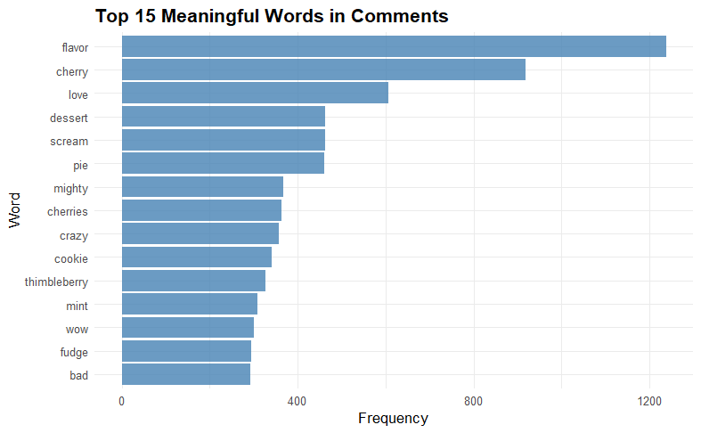

```r
meaningful_words_chart
```

#Why these words are meaningful:

Specific Flavors: “cherry”, “cookie”, “thimbleberry”, “mint”, “fudge” - These reveal which specific flavors customers are mentioning, helping identify popular options.

Experience Descriptors: “flavor”, “dessert”, “pie” - These show that customers were specifying their descriptions in the comments.

Intensity Words: “mighty”, “crazy”, “scream” - These indicate strong reactions, either positive or negative, that warrant further investigation.

#Words I Excluded and Why:

“ice”, “cream”, “cone” - Obvious words because I’m analyzing data of an ice cream company.

“i’m”, “there’s”, “can’t” - Common speech patterns without product insights.

“life”, “world”, “time”, “eat”, “buy” - Too generic for meaningful business decisions.

##Word cloud

I’ll create the word cloud by using the same custom stop list we used for the word frequency chart.

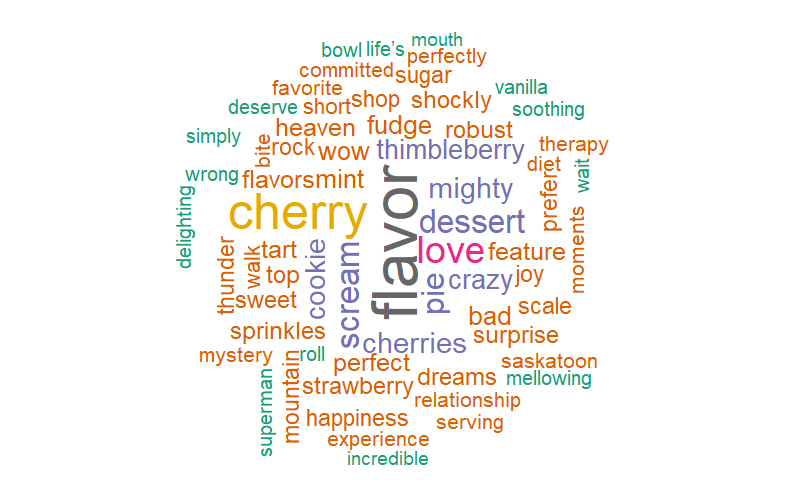

##Who are the top 5 customers by CustomerID who posts the most comments on products? For each these 5 are these positive or negative customers overall considering a measure using the afinn sentiment measure?

I identified the most active customers by comment count, then calculated their average AFINN sentiment scores. AFINN provides numerical sentiment values (-5 to +5) where negative values indicate negative sentiment and positive values indicate positive sentiment.

```r
# Loading the AFINN sentiment lexicon
afinn <- get_sentiments("afinn")

# First, identifying top 5 customers by comment count from the original data
comment_count <- posts_clean %>%
  count(CustomerID, name = "total_comments") %>%
  arrange(desc(total_comments)) %>%
  head(7)

# Calculating sentiment for these top customers
customer_sentiment <- tidy_posts %>%
  filter(CustomerID %in% comment_count$CustomerID) %>%
  inner_join(afinn, by = "word") %>%
  group_by(CustomerID) %>%
  summarise(
    total_sentiment_words = n(),  # Number of words with sentiment scores
    avg_sentiment = mean(value),  # Average AFINN score (-5 to +5)
    total_sentiment = sum(value),  # Cumulative sentiment score
    sentiment_category = case_when(
      avg_sentiment > 0.5 ~ "Strongly Positive",
      avg_sentiment > 0 ~ "Positive",
      avg_sentiment < -0.5 ~ "Strongly Negative",
      avg_sentiment < 0 ~ "Negative",
      TRUE ~ "Neutral"
    )
  ) %>%
  left_join(comment_count, by = "CustomerID") %>%
  select(CustomerID, total_comments, total_sentiment_words, avg_sentiment, total_sentiment, sentiment_category) %>%
  arrange(desc(total_comments))

# Displaying the results
customer_sentiment
```

[output not shown]

Customer Engagement: The total_comments column shows how many comments each customer has posted, indicating their level of engagement with your products.

Sentiment Measurement:

avg_sentiment: Average AFINN score ranging from -5 (very negative) to +5 (very positive)

total_sentiment: Cumulative sentiment across all their comments

sentiment_category: Classification of their overall sentiment

#Results and Analysis: Top Performers :

Customer ID #99: Highest average sentiment (1.93) with 52 cumulative points across 38 comments

Customer ID #94: Near-identical high performance (1.90 average) with 38 cumulative points across 37 comments

Strong Contributors:

Customer ID #251: Balanced positive sentiment (1.56 average) with 25 cumulative points

Customer ID #301: Consistent positive engagement (1.60 average) with 24 cumulative points

Moderate but Positive:

Customer ID #180: Lowest of the group but still solidly positive (1.18 average) with 20 cumulative points

Key Business Insights 1. The narrow range of comment counts (37-38) suggests these customers are equally engaged, while sentiment variations indicate different levels of enthusiasm.

2. Customers #99 and #94 are particularly valuable with sentiment scores approaching 2.0 - consider them for testimonials or referral programs.
3. Consistent Quality Perception: All scores are positive, indicating no major dissatisfaction issues among your most vocal customers.

##What Parlor site has the most comments? Are these negative or positive?

Across the 8 total parlor sites, we will first get a comment count and arrange them in a descending order to find the site with the highest comments. Then we will conduct a sentiment analysis on it to see if they are positive or negative.

Sentiment Assessment:

Positive (> 0): The location is meeting or exceeding customer expectations

Strongly Positive (> 0.5): Exceptional customer experiences worth replicating at other locations

Negative (< 0): Indicates operational issues needing immediate attention

Neutral (~ 0): Mixed experiences or adequate but not memorable service

```r
# Finding parlor site with most comments
parlor_analysis <- posts_clean %>%
  group_by(ParlorLocation) %>%
  summarise(comment_count = n()) %>%
  arrange(desc(comment_count)) %>%
  head(8)

# Calculating sentiment for the top parlor site
parlor_sentiment <- tidy_posts %>%
  filter(ParlorLocation == parlor_analysis$ParlorLocation[1]) %>%
  inner_join(afinn, by = "word") %>%
  summarise(
    total_sentiment_words = n(),
    avg_sentiment = mean(value),
    total_sentiment = sum(value),
    sentiment_category = case_when(
      avg_sentiment > 0.5 ~ "Strongly Positive",
      avg_sentiment > 0 ~ "Positive",
      avg_sentiment < -0.5 ~ "Strongly Negative",
      avg_sentiment < 0 ~ "Negative",
      TRUE ~ "Neutral"
    )
  )

# Combining results
parlor_results <- list(
  top_parlor_location = parlor_analysis,
  sentiment_analysis = parlor_sentiment
)

# Displaying the results
parlor_results
```

| ParlorLocation | comment_count |
| --- | --- |
| Traverse City | 8738 |
| Ludington | 5088 |
| Detroit | 4868 |
| Mackinac Island | 2230 |
| Alpena | 1940 |
| Port Huron | 1818 |
| Houghton | 1730 |
| Marquette | 1257 |

| total_sentiment_words | avg_sentiment | total_sentiment | sentiment_category |
| --- | --- | --- | --- |
| 3426 | 1.534734 | 5258 | Strongly Positive |

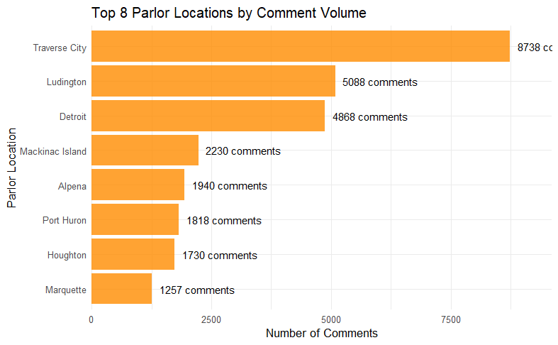

```r
# Providing visualization
parlor_analysis %>%
  ggplot(aes(x = reorder(ParlorLocation, comment_count), y = comment_count)) +
  geom_col(fill = "darkorange", alpha = 0.8) +
  geom_text(aes(label = paste0(comment_count, " comments")),
            hjust = -0.1,
            size = 3.5,
            color = "black") +
  coord_flip() +
  labs(title = "Top 8 Parlor Locations by Comment Volume",
       x = "Parlor Location",
       y = "Number of Comments") +
  theme_minimal() +
  scale_y_continuous(expand = expansion(mult = c(0, 0.1)))
```

#Results and analysis:

Sentiment Performance:

Average Sentiment Score: 1.53 (Strongly Positive)

Total Sentiment Points: 5,258 across 3,426 sentiment-bearing words

Classification: Strongly Positive - well above the 0.5 threshold for this category

Business Implications:

Exceptional Customer Experience: The strongly positive sentiment suggests Traverse City consistently delivers outstanding service and product quality.

High Engagement: The combination of high comment volume and positive sentiment indicates customers are not just visiting, but are enthusiastic enough to share their experiences.

Operational Excellence: This location appears to be a model for customer satisfaction.

##What production site has the most comments? Are these negative or positive?

Similar to the parlor site analysis, we will first find the comment count of all the 3 production sites and arrange them in descending order to see which one has the highest comments. Then we will conduct a sentiment analysis to see if they are positive or negative.

Sentiment Assessment:

Positive (> 0): The production location consistently delivers quality products that meet customer expectations

Strongly Positive (> 0.5): Exceptional product quality that delights customers

Negative (< 0): Indicates quality control issues or product formulation problems

Neutral (~ 0): Adequate but not memorable product quality

```r
# Finding production site with most comments
production_analysis <- posts_clean %>%
  group_by(ProductionLocation) %>%
  summarise(comment_count = n()) %>%
  arrange(desc(comment_count)) %>%
  head(3)

# Calculating sentiment for the top production site
production_sentiment <- tidy_posts %>%
  filter(ProductionLocation == production_analysis$ProductionLocation[1]) %>%
  inner_join(afinn, by = "word") %>%
  summarise(
    total_sentiment_words = n(),
    avg_sentiment = mean(value),
    total_sentiment = sum(value),
    sentiment_category = case_when(
      avg_sentiment > 0.5 ~ "Strongly Positive",
      avg_sentiment > 0 ~ "Positive",
      avg_sentiment < -0.5 ~ "Strongly Negative",
      avg_sentiment < 0 ~ "Negative",
      TRUE ~ "Neutral"
    )
  )

# Combining results
production_results <- list(
  top_production_location = production_analysis,
  sentiment_analysis = production_sentiment
)

# Displaying the results
production_results
```

| ProductionLocation | comment_count |
| --- | --- |
| Mount Pleasant | 12908 |
| Kalamazoo | 11774 |
| Sault Ste. Marie | 2987 |

| total_sentiment_words | avg_sentiment | total_sentiment | sentiment_category |
| --- | --- | --- | --- |
| 5017 | 1.54694 | 7761 | Strongly Positive |

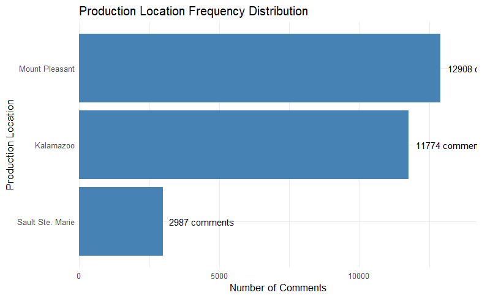

```r
# Providing Visualization (bar chart) with comment numbers
production_location_freq <- posts_clean %>%
  count(ProductionLocation, sort = TRUE)

production_location_freq %>%
  ggplot(aes(x = reorder(ProductionLocation, n), y = n)) +
  geom_col(fill = "steelblue") +
  geom_text(aes(label = paste0(n, " comments")),
            hjust = -0.1,
            size = 3.5,
            color = "black") +
  coord_flip() +
  labs(title = "Production Location Frequency Distribution",
       x = "Production Location",
       y = "Number of Comments") +
  theme_minimal() +
  scale_y_continuous(expand = expansion(mult = c(0, 0.1)))
```

```r
NA
NA
```

#Results and Analysis:

Sentiment Performance:

Average Sentiment Score: 1.55 (Strongly Positive)

Total Sentiment Points: 7,761 across 5,017 sentiment-bearing words

Classification: Strongly Positive - exceeding the 0.5 threshold significantly

##What are the top 10 most frequent comments made by customers and how many times did each comment get made?

In the comments section there are a lot of empty entries which means there were no comments. We will filter out the empty comments and find out the top ten most frequent comments and get the frequency count of those comments.

```r
#Counting the comments and filtering the empty comments
top_comments <- posts_clean %>%
  filter(Comment != "" & !is.na(Comment)) %>%
  count(Comment, sort = TRUE) %>%
  head(10)

#Displaying the results
top_comments
```

|  | Comment | n |
| --- | --- | --- |
| 1 | Hello ice cream heaven - where have you been all my life | 263 |
| 2 | If you like cherries this one's for you | 246 |
| 3 | This is crazy - whoever thought of this flavor | 244 |
| 4 | Good | 233 |
| 5 | Better than most | 232 |
| 6 | What a shockly tart Robust Cherry Surprise flavor - you've got to love cherry for this one | 232 |
| 7 | Wow. | 230 |
| 8 | Perfect Strawberry Pie | 227 |
| 9 | Really good ice cream | 226 |
| 10 | So good it's bad. What an ice cream shop | 226 |

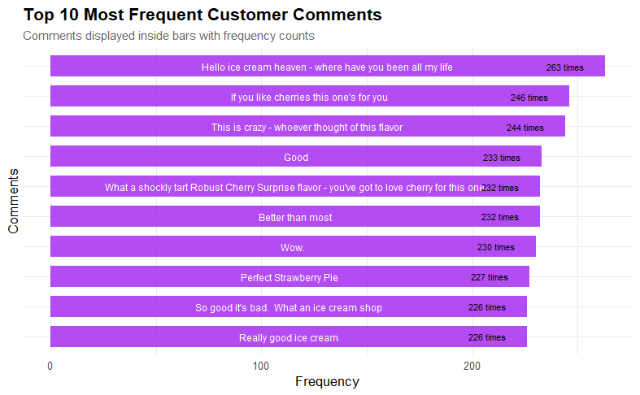

```r
# Providing Visualization of the results
top_comments %>%
  ggplot(aes(x = reorder(Comment, n), y = n)) +
  geom_col(fill = "purple", alpha = 0.8, width = 0.7) +
  geom_text(aes(label = Comment, y = n/2),
            size = 2.8,
            color = "white",
            hjust = 0.5,
            position = position_dodge(width = 0.9)) +
  geom_text(aes(label = paste(n, "times"), y = n - 10),
            size = 2.5,
            color = "black",
            hjust = 1) +
  coord_flip() +
  labs(title = "Top 10 Most Frequent Customer Comments",
       subtitle = "Comments displayed inside bars with frequency counts",
       x = "Comments",
       y = "Frequency") +
  theme_minimal() +
  theme(axis.text.y = element_blank(),
        axis.ticks.y = element_blank(),
        plot.title = element_text(face = "bold", size = 14),
        plot.subtitle = element_text(color = "gray40", size = 10))
```

##Create a network diagram based on bigrams

We will follow 4 steps for this one which are:

Step 1: Create bigrams from the data

Step 2: Count and display the most frequent bigrams

Step 3: Separate bigrams and remove stop words

Step 4: Create the network diagram visualization

```r
# Creating Bigrams
productBigram <- posts_clean %>% unnest_tokens(bigram, Comment, token = "ngrams", n = 2)

#Counting the most frequent bigrams (Top 30)
productBigram %>% count(bigram,sort=TRUE) %>% top_n(30)
```

| bigram | n |
| --- | --- |
| NA | 14724 |
| ice cream | 6343 |
| cream is | 682 |
| my ice | 663 |
| of ice | 602 |
| if you | 595 |
| for this | 450 |
| is my | 449 |
| an ice | 429 |
| willing to | 402 |

[output cut: 25 more lines]

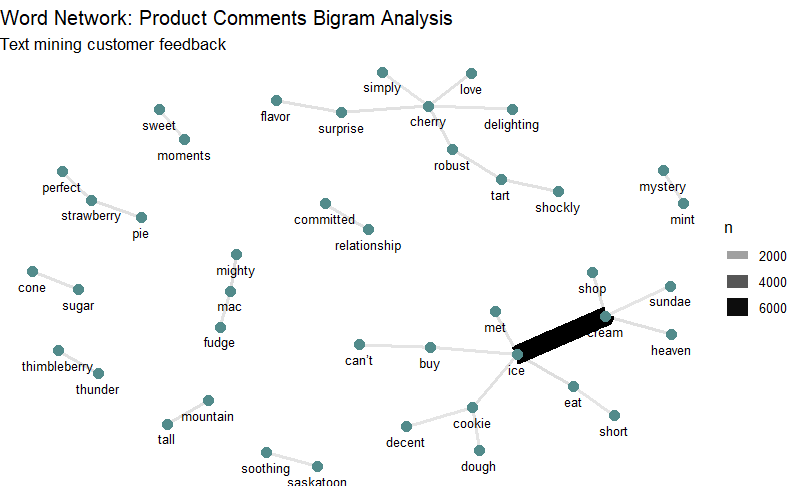

```r
#Getting rid of common words
productBigramCount <- productBigram %>% separate(bigram, c("word1", "word2"), sep = " ") %>%
        filter(!word1 %in% stop_words$word,
               !word2 %in% stop_words$word,
               !is.na(word1),
               !is.na(word2)) %>%
        count(word1, word2, sort = TRUE)

#Plotting the result
productBigramCount %>%  filter(n >= 90) %>%
  graph_from_data_frame() %>% ggraph(layout = "fr") +
  geom_edge_link(aes(edge_alpha = n, edge_width = n)) +
  geom_node_point(color = "darkslategray4", size = 3) +
  geom_node_text(aes(label = name), vjust = 1.8, size = 3) +
  labs(title = "Word Network: Product Comments Bigram Analysis",
       subtitle = "Text mining customer feedback",
       x = "", y = "") +
  theme_void()
```

##GRADS—- assuming you work for the company/organization for which these product comments have been collected, what can you infer from the data? If the company was asking you if they should take any actions based on customer feedback, what would you tell them and why?

I will try my best to create a perfect balance of technicality and relevance in this answer. I will run codes and create visualizations that are relevant and can provide meaningful insights for the company.

```r
# Understanding the sales data
sales_summary <- posts_clean %>%
  summarise(
    total_chocolate = sum(Chocolate, na.rm = TRUE),
    total_feature = sum(Feature, na.rm = TRUE),
    total_superman = sum(Superman, na.rm = TRUE),
    total_vanilla = sum(Vanilla, na.rm = TRUE),
    total_sales = total_chocolate + total_feature + total_superman + total_vanilla
  )

#Displaying the result
sales_summary
```

| total_chocolate | total_feature | total_superman | total_vanilla | total_sales |
| --- | --- | --- | --- | --- |
| 17611 | 43497 | 8632 | 17283 | 87023 |

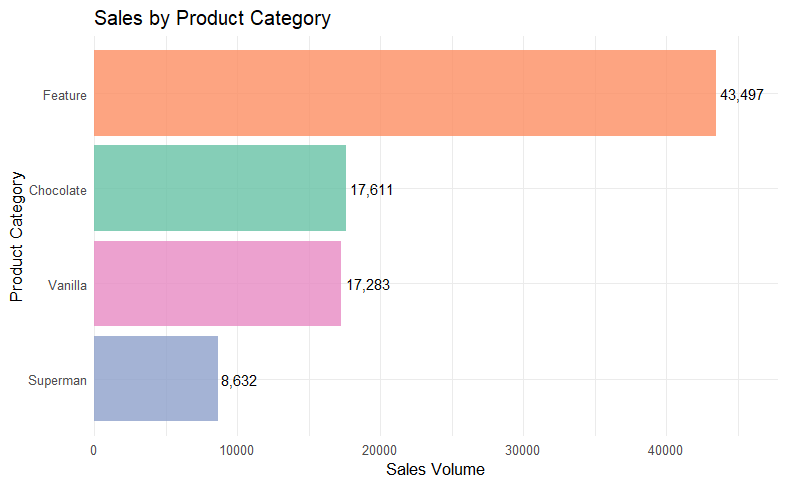

```r
# Creating a bar chart for product category sales
sales_summary_long <- sales_summary %>%
  pivot_longer(cols = c(total_chocolate, total_feature, total_superman, total_vanilla),
               names_to = "product_category",
               values_to = "sales_volume") %>%
  mutate(product_category = str_remove(product_category, "total_") %>% str_to_title())

sales_summary_long %>%
  ggplot(aes(x = reorder(product_category, sales_volume), y = sales_volume, fill = product_category)) +
  geom_col(alpha = 0.8) +
  geom_text(aes(label = scales::comma(sales_volume)),
            hjust = -0.1,
            size = 3.5,
            color = "black") +
  coord_flip() +
  scale_fill_brewer(palette = "Set2") +
  labs(title = "Sales by Product Category",
       x = "Product Category",
       y = "Sales Volume") +
  theme_minimal() +
  theme(legend.position = "none") +
  scale_y_continuous(expand = expansion(mult = c(0, 0.1)))
```

```r
# Analyzing Feature Flavor distribution and their sentiment
flavor_performance <- posts_clean %>%
  group_by(FeatureFlavor) %>%
  summarise(
    sales_volume = sum(Feature, na.rm = TRUE),
    comment_count = n(),
    unique_customers = n_distinct(CustomerID)
  ) %>%
  arrange(desc(sales_volume))

# Showing flavors by sales
head(flavor_performance, 15)
```

| FeatureFlavor | sales_volume | comment_count | unique_customers |
| --- | --- | --- | --- |
| Paw Claw Ice Cream | 4973 | 3154 | 998 |
| Sweet Dreams | 3987 | 2482 | 331 |
| Robust Cherry Surprise | 3691 | 2346 | 755 |
| Thimbleberry Thunder | 3623 | 2289 | 721 |
| Strawberry Pie | 3607 | 2244 | 750 |
| Cookie Mountain | 3414 | 2174 | 703 |
| Mighty Mac Fudge | 3252 | 2131 | 652 |
| Superman | 3025 | 1895 | 358 |
| Candyland | 2875 | 1854 | 324 |
| Maple Me Happy | 2714 | 1748 | 328 |

[output cut: 4 more lines]

```r
# Combining the sales data with sentiment analysis
flavor_sentiment <- posts_clean %>%
  group_by(FeatureFlavor) %>%
  summarise(
    sales_volume = sum(Feature, na.rm = TRUE),
    comment_count = n()
  ) %>%
  left_join(
    tidy_posts %>%
      inner_join(afinn, by = "word") %>%
      group_by(FeatureFlavor) %>%
      summarise(
        avg_sentiment = mean(value),
        total_sentiment_words = n()
      ),
    by = "FeatureFlavor"
  ) %>%
  filter(!is.na(FeatureFlavor), FeatureFlavor != "") %>%
  arrange(desc(sales_volume))

# Displaying comprehensive flavor performance
flavor_sentiment
```

| FeatureFlavor | sales_volume | comment_count | avg_sentiment | total_sentiment_words |
| --- | --- | --- | --- | --- |
| Paw Claw Ice Cream | 4973 | 3154 | 1.2385892 | 964 |
| Sweet Dreams | 3987 | 2482 | 1.2766440 | 441 |
| Robust Cherry Surprise | 3691 | 2346 | 1.8865979 | 1067 |
| Thimbleberry Thunder | 3623 | 2289 | 1.7484076 | 628 |
| Strawberry Pie | 3607 | 2244 | 1.6967005 | 788 |
| Cookie Mountain | 3414 | 2174 | 1.1821429 | 560 |
| Mighty Mac Fudge | 3252 | 2131 | 1.1685393 | 534 |
| Superman | 3025 | 1895 | 1.3617021 | 282 |
| Candyland | 2875 | 1854 | 1.0526316 | 228 |
| Maple Me Happy | 2714 | 1748 | 1.1655629 | 302 |

[output cut: 4 more lines]

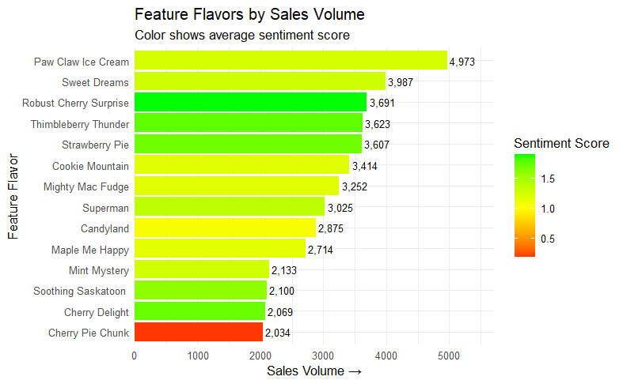

```r
# Visualizing the flavors by sales with sentiment
flavors <- flavor_sentiment %>%
  head(14) %>%
  mutate(performance_score = sales_volume * avg_sentiment)

flavors %>%
  ggplot(aes(x = reorder(FeatureFlavor, sales_volume), y = sales_volume, fill = avg_sentiment)) +
  geom_col() +
  geom_text(aes(label = scales::comma(sales_volume)),
            hjust = -0.1,
            size = 3,
            color = "black") +
  coord_flip() +
  scale_fill_gradient2(low = "red", mid = "yellow", high = "green", midpoint = 1) +
  labs(title = "Feature Flavors by Sales Volume",
       subtitle = "Color shows average sentiment score",
       x = "Feature Flavor",
       y = "Sales Volume →",
       fill = "Sentiment Score") +
  theme_minimal() +
  scale_y_continuous(expand = expansion(mult = c(0, 0.15)))
```

#Analysis and Recommendations for the company:

A short overview of Sales:

Total Sales: 87,023 units

#Feature Flavors: 43,497 units (50% of total sales)

Chocolate: 17,611 units

Vanilla: 17,283 units

Superman: 8,632 units

We observed that the feature flavors drive half of our revenue. Therefore this is where we should focus our marketing on. All ice cream companies produce basic flavors but these feature feature flavors are unique and only we produce them. So we have to leverage this absence of competitors and use it as the driving force of our marketing campaigns.

#Analysis of the Feature Flavors based on Sales Volumes and Sentiment Value:

The Customer Favorites:

Leading our flavor portfolio with exceptional customer satisfaction is Robust Cherry Surprise, which has achieved the perfect balance of commercial success and customer love. With 3,691 units sold and an outstanding sentiment score of 1.89, the highest among all top-selling flavors. Customers don’t just buy it, they genuinely adore it. Close behind are Thimbleberry Thunder and Strawberry Pie, both maintaining excellent sentiment scores of 1.75 and 1.70 respectively while moving impressive volumes of 3,623 and 3,607 units. These three flavors represent our top tier where customer enthusiasm matches strong sales performance.

The Sales Powerhouses(High Sales Volume, Decent Sentiment Value):

When it comes to pure sales dominance, Paw Claw Ice Cream stands unchallenged as our volume leader. With 4,973 units sold, it is our highest-selling feature flavor by a significant margin. This flavor demonstrates remarkable market appeal. While its sentiment score of 1.24 is solid, there’s potential to elevate the customer experience to match its commercial success. Similarly, Sweet Dreams shows strong market performance with 3,987 units sold, though it appears to rely on a smaller but more intensely loyal customer base.

#Recommendations:

So according to my analysis we should move forward with these actions immediately: